# Test a Perceptual Phenomenon

### Analyzing the Stroop Effect

In a Stroop task, participants are presented with a list of words, with each word displayed in a color of ink. The participant’s task is to say out loud the color of the ink in which the word is printed. The task has two conditions: a congruent words condition, and an incongruent words condition. In the congruent words condition, the words being displayed are color words whose names match the colors in which they are printed: for example RED, BLUE. In the incongruent words condition, the words displayed are color words whose names do not match the colors in which they are printed: for example PURPLE, ORANGE. In each case, we measure the time it takes to name the ink colors in equally-sized lists. Each participant will go through and record a time from each condition.

(1) What is the independent variable? What is the dependent variable?

**The Independent Variable:**

- Congruent & incongruent words condition

**The Dependent Variable:**

- Time taken to name ink colors

(2) What is an appropriate set of hypotheses for this task? Specify your null and alternative hypotheses, and clearly define any notation used. Justify your choices. What kind of statistical test do you expect to perform? Justify your choices.

**Null Hypothesis:** at null hypothesis we want to prove that the time of congruent values is the same as incongruent values

$H_0$ : $\mu_1$ = $\mu_2$ (mean of population for congruent values ($\mu_1$) equals mean of population for incongruent values ($\mu_2$) )

**Alternative Hypothesis:** at alt. hypothesis we want to prove that congruent values and incongruent values are not equal

$H_1$ : $\mu_1$ $\neq$ $\mu_2$ (mean of population for congruent values ($\mu_1$) not equal mean of population for incongruent values ($\mu_2$) )

**Statistical Test:** I chosen the the dependent t-test, Because we need to determine if there's statistically significant difference between mean population for congruent values and mean population for incongruent values, also we're comparing two dependent variables with each others which are nearly normaly distributed, the tailed test is because we are testing between two means whether they're equal or not

reference: https://statistics.laerd.com/statistical-guides/dependent-t-test-statistical-guide.php

https://www.quora.com/What-are-the-uses-of-t-test

(3) Report some descriptive statistics regarding this dataset. Include at least one measure of central tendency and at least one measure of variability. The name of the data file is 'stroopdata.csv'.

```python
# Perform the analysis here
import pandas as pd
import numpy as np
import matplotlib.pyplot as plt
% matplotlib inline

df=pd.read_csv('stroopdata.csv')
df.head()
```

|  | Congruent | Incongruent |
| --- | --- | --- |
| 0 | 12.079 | 19.278 |
| 1 | 16.791 | 18.741 |
| 2 | 9.564 | 21.214 |
| 3 | 8.630 | 15.687 |
| 4 | 14.669 | 22.803 |

```python
df.describe()
```

|  | Congruent | Incongruent |
| --- | --- | --- |
| count | 24.000000 | 24.000000 |
| mean | 14.051125 | 22.015917 |
| std | 3.559358 | 4.797057 |
| min | 8.630000 | 15.687000 |
| 25% | 11.895250 | 18.716750 |
| 50% | 14.356500 | 21.017500 |
| 75% | 16.200750 | 24.051500 |
| max | 22.328000 | 35.255000 |

```python
df['Congruent'].median()
```

```
14.3565
```

```python
df['Incongruent'].median()
```

```
21.017499999999998
```

Therefore,

Standard Deviation for Congruent = 3,559 & for Incongruent = 4.797

Mean for Congruent = 14.05 & For Incongruent = 22.01

Median For Congruent= 14.35 & For Incongruent = 21.01

(4) Provide one or two visualizations that show the distribution of the sample data. Write one or two sentences noting what you observe about the plot or plots.

```
Text(0.5,1,'Congruent Test Sample')
```

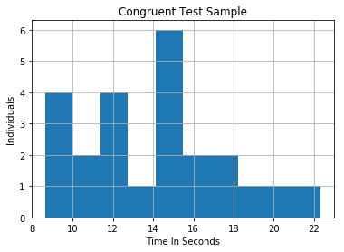

```python
df['Congruent'].hist()
plt.xlabel('Time In Seconds')
plt.ylabel('Individuals')
plt.title('Congruent Test Sample')
```

```
Text(0.5,1,'Incongruent Test Sample')
```

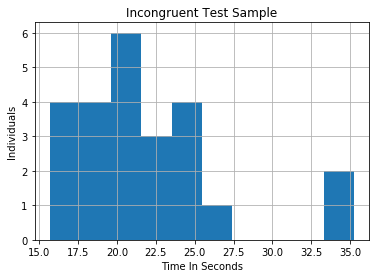

```python
df['Incongruent'].hist()
plt.xlabel('Time In Seconds')
plt.ylabel('Individuals')
plt.title('Incongruent Test Sample')
```

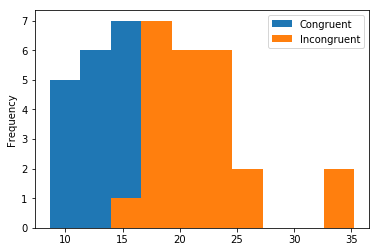

```python
df.plot(kind='hist')
```

- From Comparisons Between two test samples we see:
  - no. of individuals who took the two exams are nearly equal
  - for the same no. of individuals in the middle we see that the time taken to finish the incongruent test is larger than time taken to finish congruent test

**Reference:** how to write bullet points in markdown cell https://github.com/adam-p/markdown-here/wiki/Markdown-Here-Cheatsheet

(5) Now, perform the statistical test and report your results. What is your confidence level or Type I error associated with your test? What is your conclusion regarding the hypotheses you set up? Did the results match up with your expectations? **Hint:** Think about what is being measured on each individual, and what statistic best captures how an individual reacts in each environment.

```python
from scipy import stats
n=24 # sample size
dof= n-1 #degree of freedom
confidence_interval=0.95
stats.t.ppf(confidence_interval,dof)
```

```
1.7138715277470473
```

```python
#calculating the t-test between our two related independent variables
stats.ttest_rel(df['Congruent'], df['Incongruent'])
```

```
Ttest_relResult(statistic=-8.020706944109957, pvalue=4.1030005857111781e-08)
```

**Conclusion**:

- Since the pvalue is multiplicated to the power of -8 therefore the p value is less than the significance in confidence interval which is 0.05 so we reject the null hypothesis which states that congruent population mean will be equal to incongruent population which is not true
- the answers in last section are correlated with the observations we seen from the plots at which the incongruent group individuals took a longer time to finish the test sample